# Practical Machine Learning Project

İlker Zeybek

September 18, 2020

## Introduction

Using devices such as **Jawbone Up**, **Nike FuelBand**, and **Fitbit** it is now possible to collect a large amount of data about personal activity relatively inexpensively. These type of devices are part of the quantified self movement – a group of enthusiasts who take measurements about themselves regularly to improve their health, to find patterns in their behavior, or because they are tech geeks. One thing that people regularly do is quantify how much of a particular activity they do, but they rarely quantify how well they do it. In this project, your goal will be to use data from accelerometers on the belt, forearm, arm, and dumbell of 6 participants. They were asked to perform barbell lifts correctly and incorrectly in 5 different ways. More information is available from the website [here](http://web.archive.org/web/20161224072740/http:/groupware.les.inf.puc-rio.br/har). (see the section on the Weight Lifting Exercise Dataset).

The goal of this project is to predict the manner in which they did the exercise. This is the **classe** variable in the training set.

## Data Processing

Firstly, we have to load necessary packages and set the seed for reproducibility.

```r
library(caret)
```

```r
library(rpart)
library(rpart.plot)
library(rattle)
library(randomForest)
library(corrplot)
set.seed(12345)
```

Then we need to load train and test data into R. In this project, testing data is the final 20 cases for evaluating the project outcome.

```r
training <- read.csv("pml-training.csv")
testing  <- read.csv("pml-testing.csv")
```

After loading the data, we will create actual training and testing data that we use and evaluate our models.

```r
inTrain  <- createDataPartition(training$classe, p=0.7, list=FALSE)
TrainSet <- training[inTrain, ]
TestSet  <- training[-inTrain, ]
dim(TrainSet)
```

```
## [1] 13737   160
```

```r
dim(TestSet)
```

```
## [1] 5885  160
```

We have to clear our data in order to create efficient classification models. Firstly, we will remove features with **Nearly Zero Variance** with **nearZeroVar()** function.

```r
NZV <- nearZeroVar(TrainSet)
TrainSet <- TrainSet[, -NZV]
TestSet  <- TestSet[, -NZV]
dim(TrainSet)
```

```
## [1] 13737   104
```

```r
dim(TestSet)
```

```
## [1] 5885  104
```

After that, we will remove the features with consists mostly NA values. 95% is selected for threshold.

```r
AllNA    <- sapply(TrainSet, function(x) mean(is.na(x))) > 0.95
TrainSet <- TrainSet[, AllNA == F]
TestSet  <- TestSet[, AllNA == F]
dim(TrainSet)
```

```
## [1] 13737    59
```

```r
dim(TestSet)
```

```
## [1] 5885   59
```

Then we have to remove identification features, namely the first five features.

```r
TrainSet <- TrainSet[, -(1:5)]
TestSet  <- TestSet[, -(1:5)]
dim(TrainSet)
```

```
## [1] 13737    54
```

```r
dim(TestSet)
```

```
## [1] 5885   54
```

## Exploratory Data Analysis

Correlations among features are analysed before proceeding to the modeling phase of classification methods.

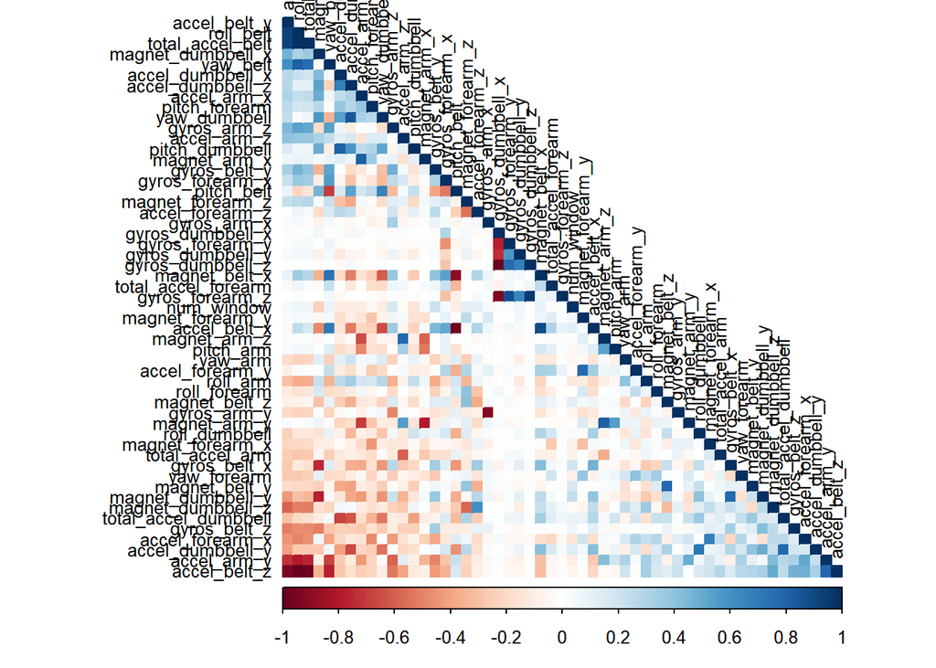

```r
corMatrix <- cor(TrainSet[, -54])
corrplot(corMatrix, order = "FPC", method = "color", type = "lower",
         tl.cex = 0.8, tl.col = rgb(0, 0, 0))
```

## Prediction Models

Famous classification methods like Random Forest, Decision Tree, and Generalized Boosted Model will be applied to the data set.

### Random Forest

```r
controlRF <- trainControl(method="cv", number=3, verboseIter=FALSE)
modFitRandForest <- train(classe ~ ., data=TrainSet, method="rf",
                          trControl=controlRF)
modFitRandForest$finalModel
```

```
##
## Call:
##  randomForest(x = x, y = y, mtry = param$mtry)
##                Type of random forest: classification
##                      Number of trees: 500
## No. of variables tried at each split: 27
##
##         OOB estimate of  error rate: 0.19%
## Confusion matrix:
##      A    B    C    D    E  class.error
## A 3905    0    0    0    1 0.0002560164
## B    6 2648    3    1    0 0.0037622272
## C    0    5 2391    0    0 0.0020868114
## D    0    0    8 2244    0 0.0035523979
## E    0    0    0    2 2523 0.0007920792
```

```r
predictRandForest <- predict(modFitRandForest, newdata=TestSet)
confMatRandForest <- confusionMatrix(table(predictRandForest, TestSet$classe))
confMatRandForest
```

```
## Confusion Matrix and Statistics
##
##
## predictRandForest    A    B    C    D    E
##                 A 1674    1    0    0    0
##                 B    0 1138    1    0    0
##                 C    0    0 1025    2    0
##                 D    0    0    0  961    0
##                 E    0    0    0    1 1082
##
## Overall Statistics
##
##                Accuracy : 0.9992
##                  95% CI : (0.998, 0.9997)
##     No Information Rate : 0.2845
##     P-Value [Acc > NIR] : < 2.2e-16
##
##                   Kappa : 0.9989
##
##  Mcnemar's Test P-Value : NA
##
## Statistics by Class:
##
##                      Class: A Class: B Class: C Class: D Class: E
## Sensitivity            1.0000   0.9991   0.9990   0.9969   1.0000
## Specificity            0.9998   0.9998   0.9996   1.0000   0.9998
## Pos Pred Value         0.9994   0.9991   0.9981   1.0000   0.9991
## Neg Pred Value         1.0000   0.9998   0.9998   0.9994   1.0000
## Prevalence             0.2845   0.1935   0.1743   0.1638   0.1839
## Detection Rate         0.2845   0.1934   0.1742   0.1633   0.1839
## Detection Prevalence   0.2846   0.1935   0.1745   0.1633   0.1840
## Balanced Accuracy      0.9999   0.9995   0.9993   0.9984   0.9999
```

### Decision Tree

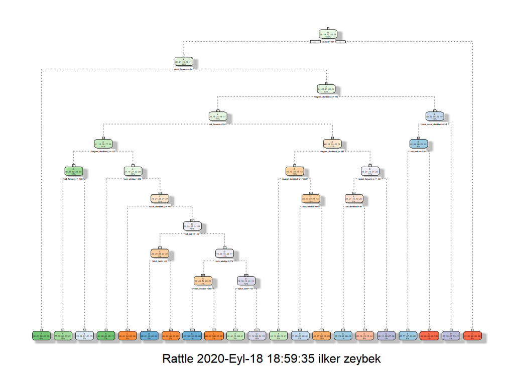

```r
modFitDecTree <- rpart(classe ~ ., data = TrainSet, method = "class")
fancyRpartPlot(modFitDecTree)
```

```r
predictDecTree <- predict(modFitDecTree, newdata = TestSet,
                          type = "class")
confMatDecTree <- confusionMatrix(table(predictDecTree, TestSet$classe))
confMatDecTree
```

```
## Confusion Matrix and Statistics
##
##
## predictDecTree    A    B    C    D    E
##              A 1502  201   59   66   74
##              B   58  660   37   64  114
##              C    4   66  815  129   72
##              D   90  148   54  648  126
##              E   20   64   61   57  696
##
## Overall Statistics
##
##                Accuracy : 0.7342
##                  95% CI : (0.7228, 0.7455)
##     No Information Rate : 0.2845
##     P-Value [Acc > NIR] : < 2.2e-16
##
##                   Kappa : 0.6625
##
##  Mcnemar's Test P-Value : < 2.2e-16
##
## Statistics by Class:
##
##                      Class: A Class: B Class: C Class: D Class: E
## Sensitivity            0.8973   0.5795   0.7943   0.6722   0.6433
## Specificity            0.9050   0.9425   0.9442   0.9151   0.9579
## Pos Pred Value         0.7897   0.7074   0.7505   0.6079   0.7751
## Neg Pred Value         0.9568   0.9033   0.9560   0.9344   0.9226
## Prevalence             0.2845   0.1935   0.1743   0.1638   0.1839
## Detection Rate         0.2552   0.1121   0.1385   0.1101   0.1183
## Detection Prevalence   0.3232   0.1585   0.1845   0.1811   0.1526
## Balanced Accuracy      0.9011   0.7610   0.8693   0.7936   0.8006
```

### Generalized Boosted Model

```r
controlGBM <- trainControl(method = "repeatedcv", number = 5, repeats = 1)
modFitGBM  <- train(classe ~ ., data=TrainSet, method = "gbm",
                    trControl = controlGBM, verbose = FALSE)
modFitGBM$finalModel
```

```
## A gradient boosted model with multinomial loss function.
## 150 iterations were performed.
## There were 53 predictors of which 52 had non-zero influence.
```

```r
predictGBM <- predict(modFitGBM, newdata=TestSet)
confMatGBM <- confusionMatrix(table(predictGBM, TestSet$classe))
confMatGBM
```

```
## Confusion Matrix and Statistics
##
##
## predictGBM    A    B    C    D    E
##          A 1669   11    0    0    0
##          B    3 1117    9    4    2
##          C    0   11 1012   20    1
##          D    2    0    5  940    5
##          E    0    0    0    0 1074
##
## Overall Statistics
##
##                Accuracy : 0.9876
##                  95% CI : (0.9844, 0.9903)
##     No Information Rate : 0.2845
##     P-Value [Acc > NIR] : < 2.2e-16
##
##                   Kappa : 0.9843
##
##  Mcnemar's Test P-Value : NA
##
## Statistics by Class:
##
##                      Class: A Class: B Class: C Class: D Class: E
## Sensitivity            0.9970   0.9807   0.9864   0.9751   0.9926
## Specificity            0.9974   0.9962   0.9934   0.9976   1.0000
## Pos Pred Value         0.9935   0.9841   0.9693   0.9874   1.0000
## Neg Pred Value         0.9988   0.9954   0.9971   0.9951   0.9983
## Prevalence             0.2845   0.1935   0.1743   0.1638   0.1839
## Detection Rate         0.2836   0.1898   0.1720   0.1597   0.1825
## Detection Prevalence   0.2855   0.1929   0.1774   0.1618   0.1825
## Balanced Accuracy      0.9972   0.9884   0.9899   0.9863   0.9963
```

## Results

The accuracy of the models proposed are:

- Random Forest : 0.9992
- Decision Tree : 0.7342
- GBM : 0.9876

Random Forest will be applied to the 20 cases given for the quiz. Results are shown below.

```r
predictTEST <- predict(modFitRandForest, newdata=testing)
predictTEST
```

```
##  [1] B A B A A E D B A A B C B A E E A B B B
## Levels: A B C D E
```